# Report Template - Updated: Methods

Author

Sara Parrish (Advisor: Dr. Seals)

Published

Oct 12, 2024

Slides: slides.html ( Go to `slides.qmd` to edit)

## Introduction

The introduction should:

## Methods - Outline Only (Still working on how to tackle analysis)

### Linear regression con be achieved using different methods

- frequentist vs. Bayesian methodology
  - frequentist
    - independent variables -> dependent variables
    - regression coefficient is a point estimate, assumed to be fixed
    - does not include prior information in its estimate
  - Bayesian
    - independent variables -> dependent variables (this doesn’t change)
    - regression coefficient is not a point estimate, but a distribution, not assumed to be a fixed value
    - incorporates prior information in its estimate

### The frequentist framework

[output not shown]

$$Y = \beta_0 + \beta_1X + \varepsilon \tag{1}$$

- $Y$ : Dependent variable, the outcome
- $\beta_0$ : y intercept
- $\beta_1$ : The regression coefficient
- $X$ : Independent variable
- $\varepsilon$ : Random error (Yan and Su 2009)
- $\hat\beta$ provides a point estimate

### The Bayesian framework

- relies on bayes rule
  - written simply as

$$Posterior = \frac{Likelihood \times Prior}{Normalization}$$

- The $Prior$ is model of prior knowledge on the subject
- The $Likelihood$ is the probability of the data given the prior
- The $Normalization$ is a constant that ensures the posterior distribution is a valid density function whose integration is equal to 1
- The $Posterior$ is the probability model that expresses an updated view of the model parameters
- From the initial parameters of the prior
- In terms of calculating probability, bayed rule can be written as

$$p(B|A) = \frac{p(A|B)\cdot p(B)}{p(A)} \tag{2}$$

- Bayes Rule allows for the calculation of inverse probability ($p(B|A) \text{ from } p(A|B)$)
  - $p(B|A) \text{ and } p(A|B)$ are conditional probabilities
  - $p(A) \text{ and } p(B)$ are marginal probabilities (Lesaffre and Lawson 2012)
- For continuous parameters, Bayes rule can be written as

$$\begin{align*}
p(\theta|y) =& \frac{ L(\theta|y)p(\theta) }{p(y)}\\
\\
p(\theta|y) \propto & \text{ }L(\theta|y)p(\theta)
\end{align*}$$

- The normalization constant ($p(y)$ above) ensures the posterior distribution is a valid distribution
  - The posterior density function can be written without this constant
- The resulting prediction is not a point estimate, but a distribution (Bayes 1763)

The Bayesian approach is derived with Bayes’ theorem wherein the posterior distribution, the updated belief about the parameter given the data, is proportional to the conditional density of $D$ given $\theta$, $f(D|\theta)$, and the prior density of $\theta$, $f(\theta)$. The former is known as the likelihood function and would comprise the new data for analysis while the latter allows for the incorporation of prior knowledge regarding $\theta$(Yan and Su 2009).

$$f(\theta|D) \propto L(\theta|D)f(\theta) \tag{1}$$

### Prior Selection

- Unsure, still trying to get any analysis to work
- Might compare a “prior” using data from prior years within same dataset to a flat prior

### Statistical programming

- (R Core Team 2023)
- (Bürkner 2021)
- (Wickham et al. 2019)
- (Wickham et al. 2023)
- (Gabry et al. 2019)
- (Wickham, Vaughan, and Girlich 2023)

****Do I only include packages used in analysis, outside of EDA here? ****Do I include packages like dplyr that aren’t specific to Bayesian analysis here or just in the references?

## Analysis and Results

### Data Exploration and Visualization

```r
# loading packages
library(tidyverse)
library(knitr)
library(ggthemes)
library(ggrepel)
library(dslabs)
```

```r
# Load Data
kable(head(murders))
```

| state | abb | region | population | total |
| --- | --- | --- | --- | --- |
| Alabama | AL | South | 4779736 | 135 |
| Alaska | AK | West | 710231 | 19 |
| Arizona | AZ | West | 6392017 | 232 |
| Arkansas | AR | South | 2915918 | 93 |
| California | CA | West | 37253956 | 1257 |
| Colorado | CO | West | 5029196 | 65 |

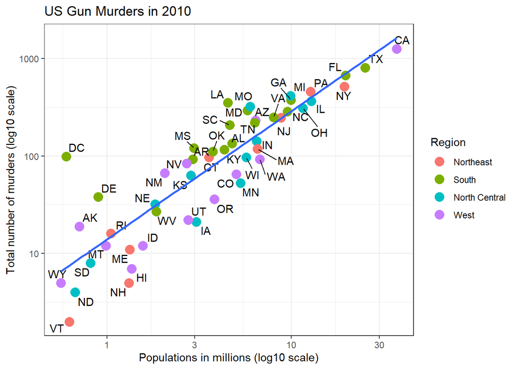

```r
ggplot1 = murders %>% ggplot(mapping = aes(x=population/10^6, y=total))

  ggplot1 + geom_point(aes(col=region), size = 4) +
  geom_text_repel(aes(label=abb)) +
  scale_x_log10() +
  scale_y_log10() +
  geom_smooth(formula = "y~x", method=lm,se = F)+
  xlab("Populations in millions (log10 scale)") +
  ylab("Total number of murders (log10 scale)") +
  ggtitle("US Gun Murders in 2010") +
  scale_color_discrete(name = "Region")+
      theme_bw()
```

## References

Bayes, T. 1763. “An Essay Towards Solving a Problem in the Doctrine of Chances. 1763.”

Bürkner, Paul-Christian. 2021. “Bayesian Item Response Modeling in R with brms and Stan.” *Journal of Statistical Software* 100 (5): 1–54. https://doi.org/10.18637/jss.v100.i05.

Gabry, Jonah, Daniel Simpson, Aki Vehtari, Michael Betancourt, and Andrew Gelman. 2019. “Visualization in Bayesian Workflow.” *J. R. Stat. Soc. A* 182: 389–402. https://doi.org/10.1111/rssa.12378.

Lesaffre, Emmanuel, and Andrew B Lawson. 2012. *Bayesian Biostatistics*. 1st ed. Somerset: John Wiley & Sons, Ltd. https://doi.org/https://doi.org/10.1002/9781119942412.

R Core Team. 2023. *R: A Language and Environment for Statistical Computing*. Vienna, Austria: R Foundation for Statistical Computing. https://www.R-project.org/.

Wickham, Hadley, Mara Averick, Jennifer Bryan, Winston Chang, Lucy D’Agostino McGowan, Romain François, Garrett Grolemund, et al. 2019. “Welcome to the tidyverse.” *Journal of Open Source Software* 4 (43): 1686. https://doi.org/10.21105/joss.01686.

Wickham, Hadley, Romain François, Lionel Henry, Kirill Müller, and Davis Vaughan. 2023. *Dplyr: A Grammar of Data Manipulation*. https://CRAN.R-project.org/package=dplyr.

Wickham, Hadley, Davis Vaughan, and Maximilian Girlich. 2023. *Tidyr: Tidy Messy Data*. https://CRAN.R-project.org/package=tidyr.

Yan, Xin, and Xiao Gang Su. 2009. *Linear Regression Analysis: Theory and Computing*. Singapore: World Scientific Publishing. https://ebookcentral.proquest.com/lib/uwf/reader.action?docID=477274&ppg=318&pq-origsite=primo.